# Build an empirical interaction matrix constrained by size of organisms.

Author

Thelma Panaïotis

## Read data

```r
# Read plankton and images
plankton <- read_parquet("data/00.plankton_clean.parquet") # no need to use the X correction here
#images <- read_parquet("data/00.images_clean.parquet")

# List taxonomic groups
taxa <- plankton %>% select(taxon) %>% distinct() %>% pull(taxon) %>% sort()
# Drop unwanted groups
taxa <- setdiff(taxa, c("Collodaria_colonial", "Rhizaria"))
plankton <- plankton %>% filter(taxon %in% taxa)

# Convert ESD from px to mm
plankton <- plankton %>% mutate(esd = esd * 51 / 1000)
```

## Explore ESD values per taxonomic group

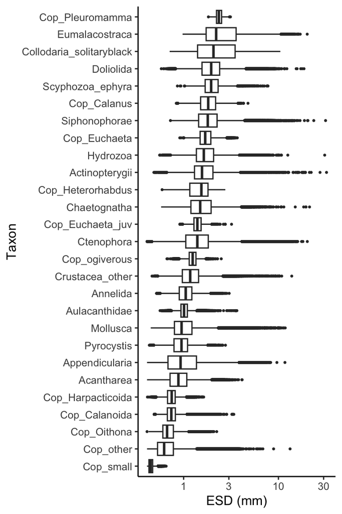

```r
# Compute median ESD for each group for a nice ordered plot
plankton <- plankton %>%
  group_by(taxon) %>%
  mutate(median_esd = median(esd)) %>%
  ungroup()

ggplot(plankton) +
  geom_boxplot(aes(x = fct_reorder(taxon, median_esd), y = esd), outlier.size = 0.5) +
  scale_y_log10() +
  labs(x = "Taxon", y = "ESD (mm)") +
  coord_flip() +
  theme_classic()
```

## Explore predator:prey size ratios

For a predator to feed on a prey, it typically has to be larger than the prey. Actually, there is an optimal predator to prey size ratio (PPSR) for each predator.

Let’s start with a given taxon as predator, with a given optimal PPSR. Let’s choose another taxon as prey. To estimate how likely the predator is to feed on the prey, we can use size distributions to compute the probability that the PPSR falls in the optimal range. For this, we randomly select 10,000 organisms in the predator taxon and 10,000 organisms in the prey taxon. We then compute 10,000 PPSR values, and count how many of them fall in the optimal range.

We’ll try various PPSR ranges, centred on values from 2 to 10, on a log-scale:

- [5; 20], centred on 10
- [4; 16], centred on 8
- [3; 12], centred on 6
- [2; 8], centred on 4
- [1; 4], centred on 2

```r
# Set up parallel processing plan
plan(multisession, workers = 8)

# Number of objects to randomly sample in each group
n_sam <- 10000

# Pre-sample each taxon in advance and store results in a list
sampled_plankton <- plankton %>%
  group_by(taxon) %>%
  slice_sample(n = n_sam) %>%
  ungroup() %>%
  select(taxon, esd) %>%
  group_by(taxon)
sampled_plankton <- sampled_plankton %>%
  group_split() %>%
  set_names(unlist(group_keys(sampled_plankton)))   # Named list for easy access by taxon name

# Generate all possible predator-prey pairs and expand for each opt_pp range
taxa_pairs <- crossing(predator = taxa, prey = taxa) %>%
  filter(predator != prey) %>%
  mutate(opt_pp = list(list(c(5, 20), c(4, 16), c(3, 12), c(2, 8), c(1, 4)))) %>%
  unnest(opt_pp)  # Flatten list to duplicate rows per each opt_pp range

# Create the plankton subsets for each predator-prey pair by pulling from pre-sampled data
taxa_pairs <- taxa_pairs %>%
  mutate(
    plankton_subset = map2(predator, prey, ~bind_rows(
      sampled_plankton[[.x]] %>%
        slice_sample(n = min(nrow(sampled_plankton[[.x]]), nrow(sampled_plankton[[.y]]))) %>%
        mutate(id = 1:n()),
      sampled_plankton[[.y]] %>%
        slice_sample(n = min(nrow(sampled_plankton[[.x]]), nrow(sampled_plankton[[.y]]))) %>%
        mutate(id = 1:n())
    ))
  )

# Helper function to calculate proportion in a single optimal range for a predator-prey pair
calc_prop_pp_in <- function(predator, prey, opt_pp_range, plankton_subset) {
  plankton_subset %>%
    pivot_wider(names_from = taxon, values_from = esd) %>%
    mutate(
      pp = .data[[predator]] / .data[[prey]],
      pp_in = between(pp, opt_pp_range[1], opt_pp_range[2])
    ) %>%
    summarise(prop_pp_in = mean(pp_in, na.rm = TRUE)) %>%
    pull(prop_pp_in)
}

# Apply the function in parallel using future_pmap_dbl to handle each opt_pp range separately
prop_ppsr <- taxa_pairs %>%
  mutate(
    prop_pp_in = future_pmap_dbl(
      list(predator, prey, opt_pp, plankton_subset),
      calc_prop_pp_in
    )
  ) %>%
  select(predator, prey, opt_pp, prop_pp_in)%>%
  mutate(opt_pp = paste0(opt_pp) %>% fct_inorder())

# Shut down the parallel plan
plan(sequential)

# Summary of results
summary(prop_ppsr)
```

```
   predator             prey                opt_pp      prop_pp_in
 Length:3510        Length:3510        c(5, 20):702   Min.   :0.00000
 Class :character   Class :character   c(4, 16):702   1st Qu.:0.00000
 Mode  :character   Mode  :character   c(3, 12):702   Median :0.01065
                                       c(2, 8) :702   Mean   :0.15365
                                       c(1, 4) :702   3rd Qu.:0.17485
                                                      Max.   :1.00000
```

We can plot the distribution of the proportion of PPSR falling in the optimal range for each range value.

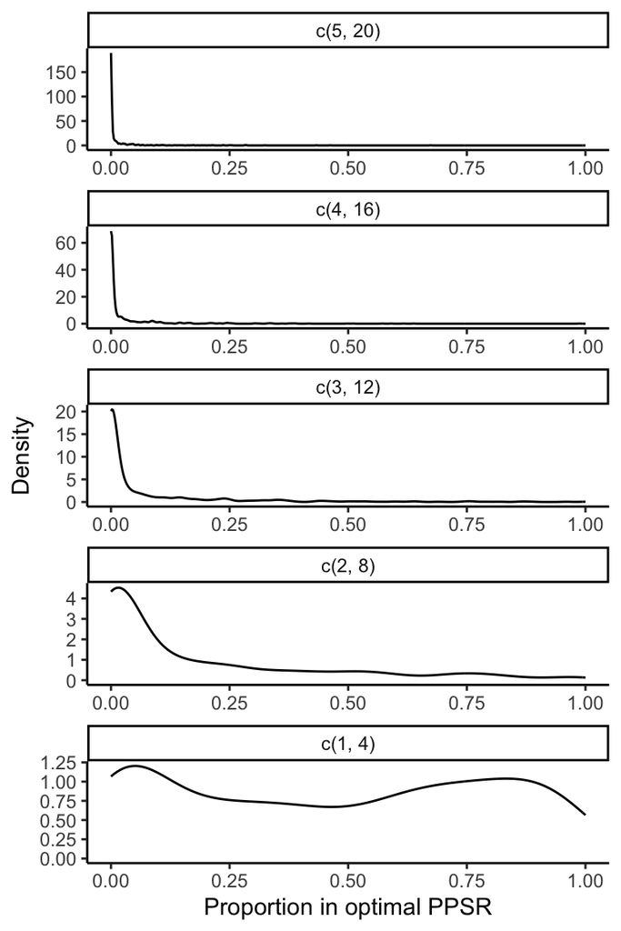

```r
ggplot(prop_ppsr) +
  geom_density(aes(x = prop_pp_in)) +
  xlim(0, 1) +
  labs(x = "Proportion in optimal PPSR", y = "Density") +
  facet_wrap(~opt_pp, scales = "free", ncol = 1) +
  theme_classic()
```

We can also plot these values in a matrix.

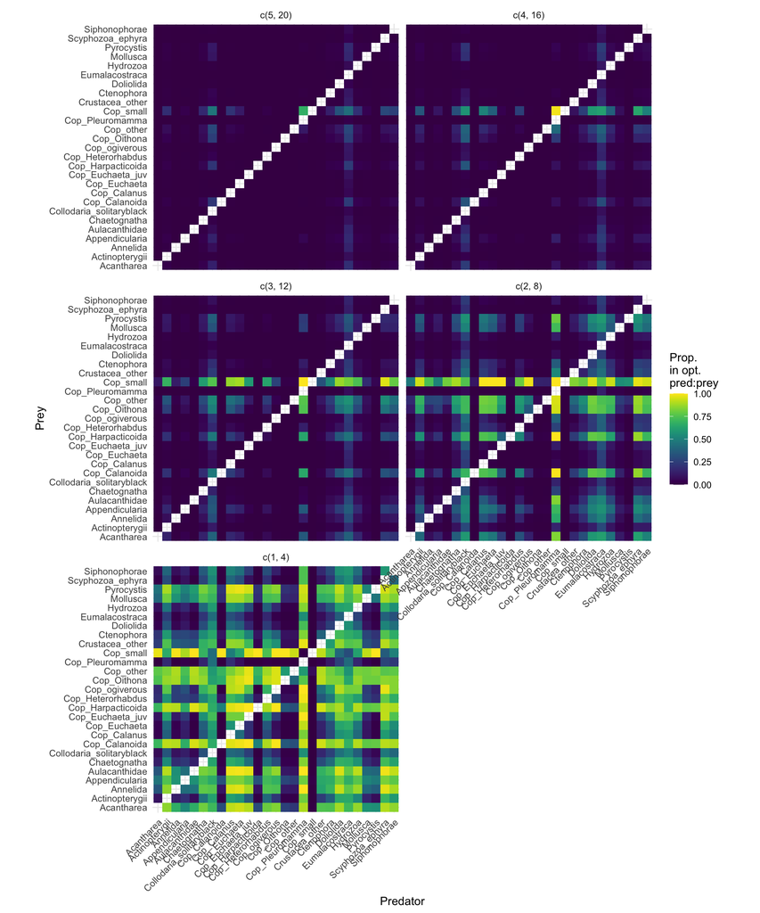

```r
ggplot(prop_ppsr) +
  geom_tile(aes(x = predator, y = prey, fill = prop_pp_in)) +
  scale_fill_viridis_c(limits = c(0, 1)) +
  labs(x = "Predator", y = "Prey", fill = "Prop.\nin opt.\npred:prey") +
  coord_fixed() +
  facet_wrap(~opt_pp, ncol = 2) +
  theme(axis.text.x = element_text(angle = 45, hjust = 1))
```

## Compare with distance-based matrix

Load the distance based matrix and process it.

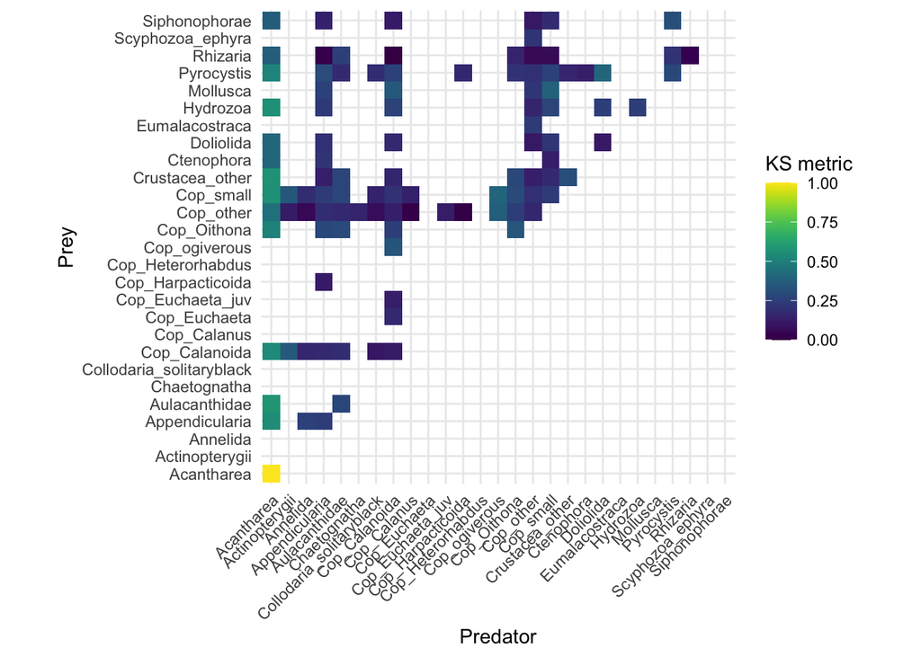

```r
load("data/07.ks_matrix.Rdata")

# Plot our original matrix
ggplot(df_mat_ks) +
  geom_tile(aes(x = t1, y = t2, fill = ks)) +
  scale_fill_viridis_c(limits = c(0, 1), na.value = NA) +
  labs(x = "Predator", y = "Prey", fill = "KS metric") +
  coord_fixed() +
  theme(axis.text.x = element_text(angle = 45, hjust = 1))
```

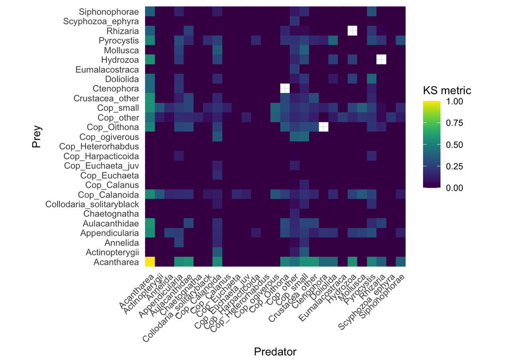

```r
# First, we need to make the KS matrix symmetric
# For this, we create a second version of the matrix but we swap t1 and t2
df_mat_ks_sym <- df_mat_ks %>%
  # swap column names using a temporary column
  rename(tmp = t1, t1 = t2) %>%
  rename(t2 = tmp) %>%
  # reorganise columns
  select(t1, t2, ks) %>%
  # bind with the original matrix
  bind_rows(df_mat_ks)

# Replace NA by zeros (i.e. no interaction)
df_mat_ks_sym <- df_mat_ks_sym %>% mutate(ks = replace_na(ks, 0))

# Plot again
ggplot(df_mat_ks_sym) +
  geom_tile(aes(x = t1, y = t2, fill = ks)) +
  scale_fill_viridis_c(limits = c(0, 1), na.value = NA) +
  labs(x = "Predator", y = "Prey", fill = "KS metric") +
  coord_fixed() +
  theme(axis.text.x = element_text(angle = 45, hjust = 1))
```

```r
# Good
```

Let’s now compare the size-based matrices and the distance-based one.

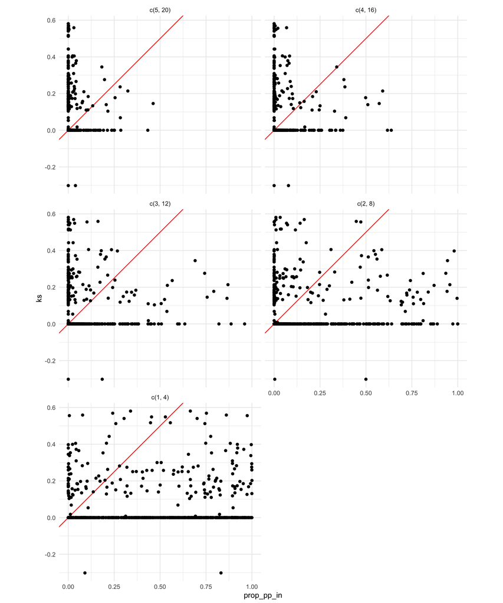

```r
comp <- prop_ppsr %>%
  # join size-based and distance-based
  left_join(df_mat_ks_sym %>% rename(predator = t1, prey = t2), by = join_by(predator, prey)) %>%
  # compate difference in both metrics
  mutate(diff = prop_pp_in - ks)

comp %>%
  ggplot() +
  geom_abline(slope = 1, intercept = 0, colour = "red") +
  geom_point(aes(x = prop_pp_in, y = ks)) +
  coord_fixed() +
  facet_wrap(~opt_pp, ncol = 2)
```

Let’s now have a look at the differences.

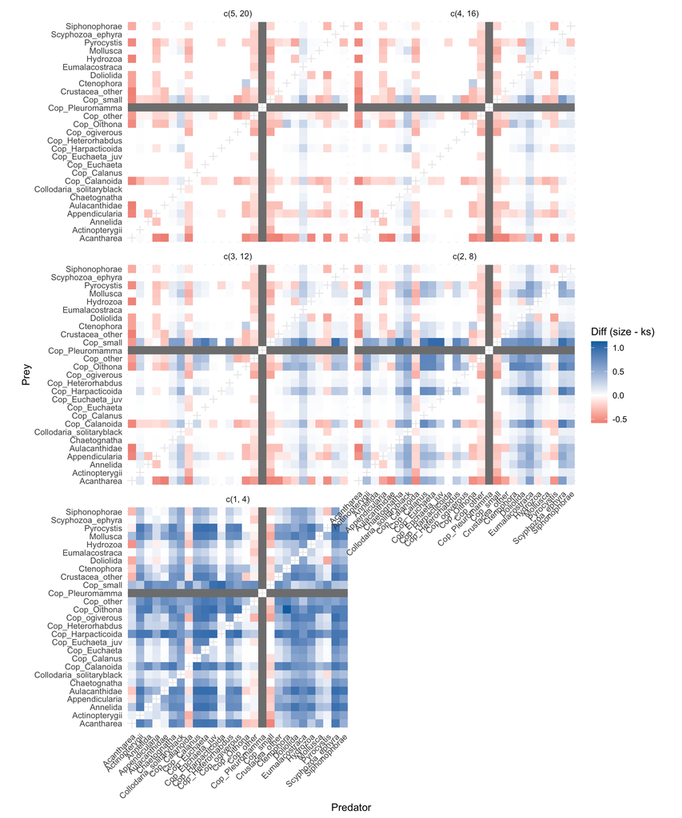

```r
# Plot the differences as matrices
ggplot(comp) +
  geom_tile(aes(x = predator, y = prey, fill = diff)) +
  #scale_fill_viridis_c(limits = c(0, 1)) +
  scale_fill_gradient2(low = "#ca0020", high = "#0571b0") +
  labs(x = "Predator", y = "Prey", fill = "Diff (size - ks)") +
  coord_fixed() +
  facet_wrap(~opt_pp, ncol = 2) +
  theme(axis.text.x = element_text(angle = 45, hjust = 1))
```

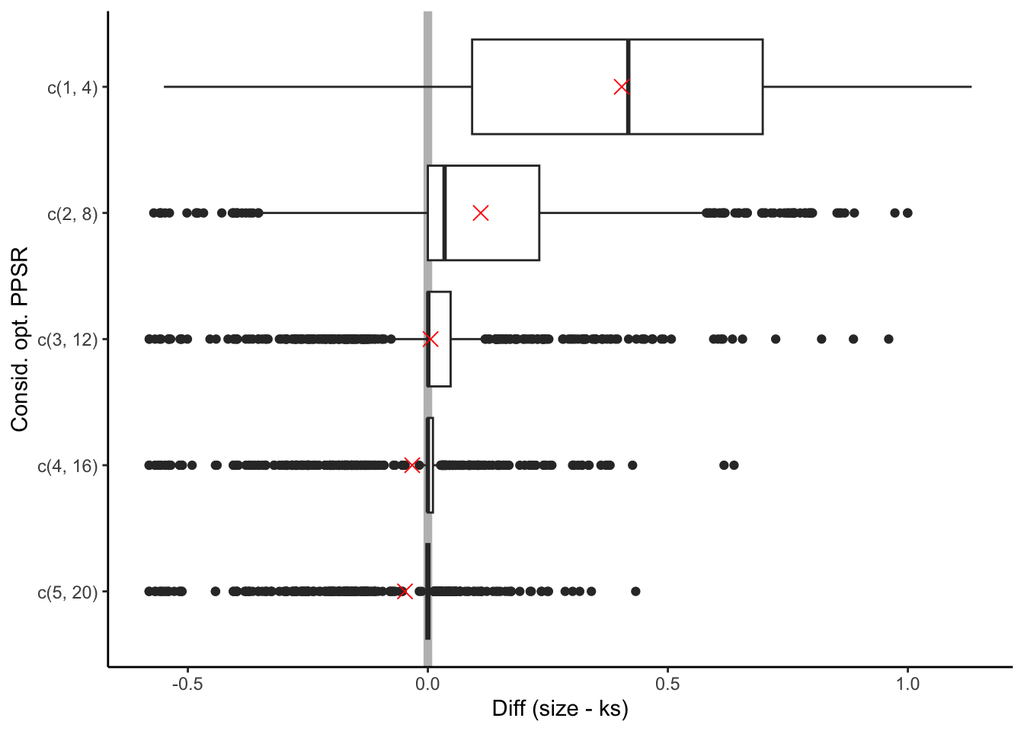

```r
# Plot the distribution of differences
ggplot(comp, aes(x = diff, y = opt_pp)) +
  geom_vline(xintercept = 0, colour = "grey", linewidth = 2) +
  geom_boxplot() +
  stat_summary(fun = mean, geom = "point", colour = "red", shape = 4, size = 3) +
  labs(x = "Diff (size - ks)", y = "Consid. opt. PPSR") +
  theme_classic()
```